# Big Mart for Grocery Shopping

## by Fadia Saleh

## Investigation Overview

> In this investigation I wanted to know what is the most factors that affect the price, after the bivaruite visiualization i found out that the main focus should be on (Item_Type,Item_Fat_Content,Item_MRP) coloumns which represents Item_Type : products, Item_Fat_Content: fats in each product type, Item_MRP: maximum retail price

## Dataset Overview

> Data contains maximum retail price of different products types with different distrubution between low fats and regular fat content from Big Mart grocery stores

## Pricing Based on the Products Type

> In here we can see that the pricing is affected based on the product type not the availability of the product in the store

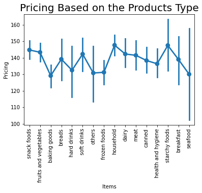

## Effect of Fat Content products on The Price

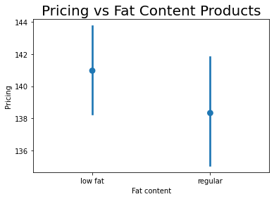

## Effect of Both Fat Content Products Factor and Product Type Factor on The Price

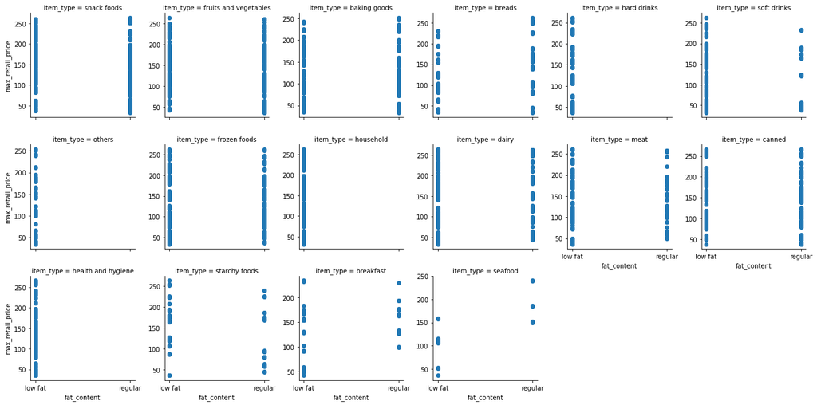